# Midterm Test

Author

Steven Todd McIntyre II

## Install Dependencies

```r
library(tidyverse)
library(glue)
library(here)
library(rio)
library(janitor)
library(ggtext)
```

## Part A: Data

```r
# create function
download_file <- function(year) {
  link <- glue::glue("https://www.oregon.gov/ode/educator-resources/assessment/TestResults20{year}/pagr_schools_ela_raceethnicity_{year-1}{year}.xlsx")
  rio::import(link, setclass = "tibble", na = c("-", "--", "*"))
}
```

### 1. (10 points)

Use the function above to download all of the data from the 2014-15 to 2017-18 school years and bind it into a single data frame, using a single function (i.e., one line of code). Note, this may take a minute or two to run, depending on your Internet speed.

```r
# use function
ode_data <- map_dfr(15:18, download_file)

ode_data
```

```
# A tibble: 110,943 × 21
   `Academic Year` `District ID` District   `School ID` School           Subject
   <chr>                   <dbl> <chr>            <dbl> <chr>            <chr>
 1 2014-2015                2063 Adel SD 21         498 Adel Elementary… Englis…
 2 2014-2015                2063 Adel SD 21         498 Adel Elementary… Englis…
 3 2014-2015                2063 Adel SD 21         498 Adel Elementary… Englis…
 4 2014-2015                2063 Adel SD 21         498 Adel Elementary… Englis…
 5 2014-2015                2063 Adel SD 21         498 Adel Elementary… Englis…
 6 2014-2015                2063 Adel SD 21         498 Adel Elementary… Englis…
 7 2014-2015                2063 Adel SD 21         498 Adel Elementary… Englis…
 8 2014-2015                2063 Adel SD 21         498 Adel Elementary… Englis…
 9 2014-2015                2063 Adel SD 21         498 Adel Elementary… Englis…
10 2014-2015                2063 Adel SD 21         498 Adel Elementary… Englis…
# ℹ 110,933 more rows
# ℹ 15 more variables: `Student Group` <chr>, `Grade Level` <chr>,
#   `Number Proficient (Level 3 or 4)` <chr>,
#   `Percent Proficient (Level 3 or 4)` <chr>, `Number Level 4` <dbl>,
#   `Percent Level 4` <dbl>, `Number Level 3` <dbl>, `Percent Level 3` <dbl>,
#   `Number Level 2` <dbl>, `Percent Level 2` <dbl>, `Number Level 1` <dbl>,
#   `Percent Level 1` <dbl>, `Number of Participants` <dbl>, …
```

Conduct some basic data cleaning to make your data file look like the following.

- Filter for only student groups coded as “White” or “Hispanic/Latino”.
- Select variables related to the number of students in each of the levels (1 through 4), and not percentages or combined levels.
- Remove any row that has missing data in any of the n variables

```r
# clean data
ode_data_clean <- ode_data |>
  clean_names() |>
  filter(student_group == "White" | student_group=="Hispanic/Latino") |>
  select(academic_year, district, school, student_group, grade_level, number_level_1, number_level_2, number_level_3, number_level_4) |>
  pivot_longer(
    c(number_level_1, number_level_2, number_level_3, number_level_4),
    names_to = "level",
    names_prefix = "number_level_",
    values_to = "n",
    values_drop_na = TRUE
  )

ode_data_clean
```

```
# A tibble: 90,576 × 7
   academic_year district     school       student_group grade_level level     n
   <chr>         <chr>        <chr>        <chr>         <chr>       <chr> <dbl>
 1 2014-2015     Adrian SD 61 Adrian Elem… Hispanic/Lat… Grade 3     1         2
 2 2014-2015     Adrian SD 61 Adrian Elem… Hispanic/Lat… Grade 3     2         1
 3 2014-2015     Adrian SD 61 Adrian Elem… Hispanic/Lat… Grade 3     3         2
 4 2014-2015     Adrian SD 61 Adrian Elem… Hispanic/Lat… Grade 3     4         1
 5 2014-2015     Adrian SD 61 Adrian Elem… Hispanic/Lat… Grade 6     1         2
 6 2014-2015     Adrian SD 61 Adrian Elem… Hispanic/Lat… Grade 6     2         3
 7 2014-2015     Adrian SD 61 Adrian Elem… Hispanic/Lat… Grade 6     3         2
 8 2014-2015     Adrian SD 61 Adrian Elem… Hispanic/Lat… Grade 6     4         0
 9 2014-2015     Adrian SD 61 Adrian Elem… Hispanic/Lat… Grade 7     1         2
10 2014-2015     Adrian SD 61 Adrian Elem… Hispanic/Lat… Grade 7     2         2
# ℹ 90,566 more rows
```

### 2. (10 points)

Sum the n across grades and school for each district within each academic year, student group, and level. Calculate the number of schools (unique schools listed) for each district. Also move your data to a wider format where the student groups become new columns, filled by the district n. Remove districts that did not report numbers for one or both student groups (i.e., drop missing data from the new columns).

```r
school_counts <- ode_data_clean |>
  group_by(district) |>
  summarize(n_schools = n_distinct(school))

# I asked chatgpt about how, given the code below that I wrote (prior to the left_join), to add in the column n_schools and have it only be by district, not by every group. It said to create it separately then join, so I created it separately above and joined it at the bottom of this chunk. I tried not to look at the exact code it gave me so I could troubleshoot myself.
ode_sum <- ode_data_clean |>
  group_by(academic_year, district, student_group, level) |>
  summarise(n_sum = sum(n), .groups = "drop") |>
  pivot_wider(
    names_from = student_group,
    values_from = n_sum
  ) |>
  clean_names() |>
  filter(!is.na(hispanic_latino) & !is.na(white)) |>
  left_join(school_counts) |>
  arrange(district)
ode_sum
```

```
# A tibble: 1,948 × 6
   academic_year district     level hispanic_latino white n_schools
   <chr>         <chr>        <chr>           <dbl> <dbl>     <int>
 1 2014-2015     Adrian SD 61 1                   6     8         2
 2 2014-2015     Adrian SD 61 2                   6    17         2
 3 2014-2015     Adrian SD 61 3                   6    23         2
 4 2014-2015     Adrian SD 61 4                   1    22         2
 5 2015-2016     Adrian SD 61 1                   5     4         2
 6 2015-2016     Adrian SD 61 2                   3    15         2
 7 2015-2016     Adrian SD 61 3                   5    39         2
 8 2015-2016     Adrian SD 61 4                   0    36         2
 9 2016-2017     Adrian SD 61 1                   2     4         2
10 2016-2017     Adrian SD 61 2                   0    19         2
# ℹ 1,938 more rows
```

## Part B: Achievement Disparities

```r
#remotes::install_github("datalorax/gapr")

library(gapr)
#ode_sum[1:4, ] |> # data source - just first four rows for first district
#  estimate_v("white", "hispanic_latino") # columns for reference/focal groups
```

### 1. (15 points)

Estimate the average achievement differences in terms of an effect size for every school district in the state that reported data on both student groups (i.e., using the data we created above), for each academic year. Conduct this analysis twice, once using group_by() |> nest() and map() and once using nest_by() |> summarize().

```r
# this is my original code, which didn't work because, for some reason, estimate_v is failing on a few items

#analysis1 <- ode_sum |>
#  group_by(academic_year, district) |>
#  nest() |>
#  mutate(
#    v_estimate = map(data, ~estimate_v(.x, "white", "hispanic_latino")),
#    v = map_dbl(v_estimate, "v")
#  )

# I pasted the above code into chatGPT and asked it how I can just remove those rows where the analysis fails, since analysis2 just seems to be automatically removing them.

# The precise prompt was [pasted code] + "The above is using estimate_v to do an analysis on each district by academic year, but whenever estimate_v returns an empty data frame, v can't be determined and it throws an error..."

# after it replied, I added "what if i want to just remove the empty rows"

# it gave me the following:

analysis1 <- ode_sum |>
  group_by(academic_year, district) |>
  nest() |>
  mutate(
    v_estimate = map(data, ~estimate_v(.x, "white", "hispanic_latino"))
  ) |>
  filter(map_lgl(v_estimate, ~nrow(.x) > 0 && "v" %in% names(.x))) |>
  mutate(
    v = map_dbl(v_estimate, ~.x$v[1])
  )
```

```r
# nest_by + summarize
analysis2 <- ode_sum |>
  ungroup() |>
  nest_by(academic_year, district) |>
  summarize(
    data = list(data),
    v_estimate = list(estimate_v(data, "white", "hispanic_latino") ),
    # had to ask a similar question of chatgpt here as in analysis 1
    v = {
      if (nrow(v_estimate) == 0) NA_real_
      else v_estimate[["v"]]
    }
  )  |>
  filter (!is.na(v))
```

```
`summarise()` has converted the output from a rowwise data frame to a grouped
data frame.
ℹ Summaries were computed rowwise.
ℹ Output is grouped by academic_year and district.
ℹ Use `summarise(.groups = "keep")` to silence this message.
```

### 2. (10 points)

Reproduce the following plot to confirm that the estimates are equivalent across methods.

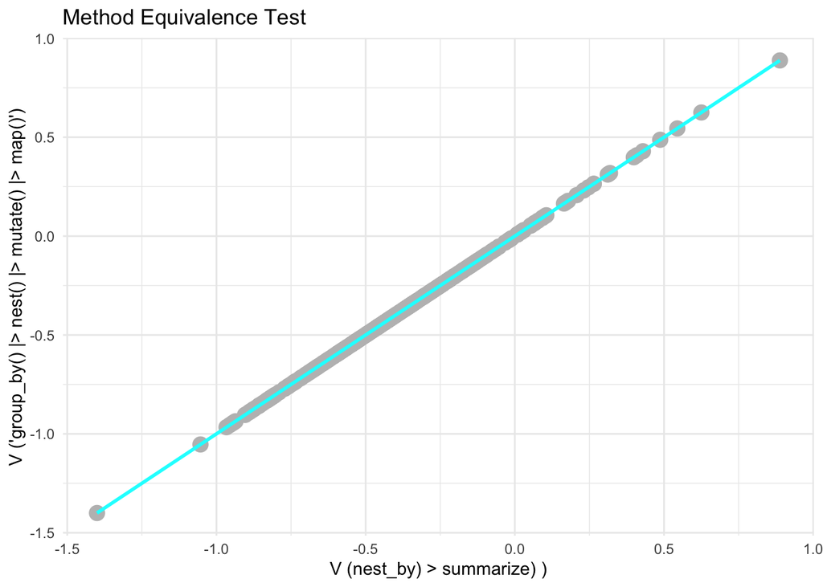

```r
analysis1 |>
  mutate(v1 = v) |>
  select(district, v1) |>
  left_join(select(mutate(analysis2, v2 = v), district, v2)) |>
  ggplot(aes(x = v2, y = v1)) +
    geom_point(size = 4, color = "grey") +
    geom_smooth(method = lm, color = "cyan", size = 1) +
    theme_minimal() +
    labs(
      title = "Method Equivalence Test",
      x = "V (nest_by) > summarize) )",
      y = "V ('group_by() |> nest() |> mutate() |> map()')"
    )
```

### 3. (15 points)

The plot below shows the achievement difference estimates for one school district across years. Produce a similar plot to the below for each of the first 100 school districts. Once you’ve created all the plots, reproduce them again using an alternative method. Make sure you don’t miss the caption noting the number of schools in the district.

```r
dists <- unique(analysis2$district)[1:100]

analysisprime <- analysis2 |>
  filter(district %in% dists) |>
  summarize(
    v = v,
    n_schools = data[[1]]["n_schools"][[1]][[1]],
    v_se = v_estimate[[1]][["v_se"]][[1]]
  )
```

```
`summarise()` has regrouped the output.
ℹ Summaries were computed grouped by academic_year and district.
ℹ Output is grouped by academic_year.
ℹ Use `summarise(.groups = "drop_last")` to silence this message.
ℹ Use `summarise(.by = c(academic_year, district))` for per-operation grouping
  (`?dplyr::dplyr_by`) instead.
```

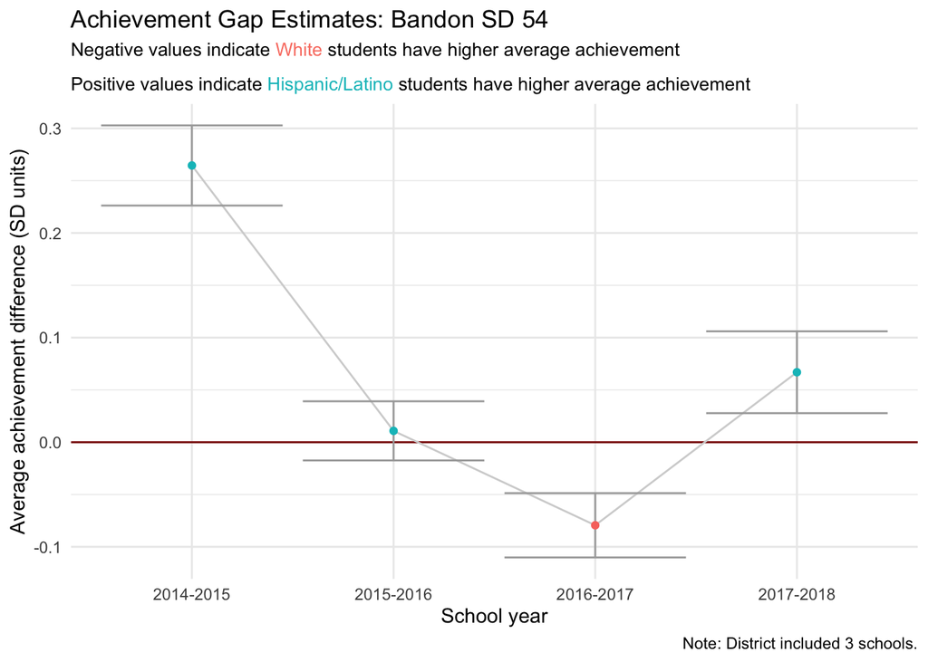

```r
# method 1: group_by, nest, mutate, map2
ode_plots1 <- analysisprime |>
  ungroup() |>
  group_by(district) |>
  nest() |>
  mutate(
    plot = map2(data, district,
                ~.x |>
                  ggplot(aes(x=academic_year)) +
                    # asked gemini how to make the next line "how to make
                    # error bars for a geom point based on an error value"
                    theme_minimal() +
                    geom_hline(yintercept = 0, color = "darkred") +
                    geom_line(aes(y=v), color = "lightgrey", group = 1, size = 0.5) +
                    geom_errorbar(aes(ymin = v - v_se, ymax = v + v_se), color = "darkgrey") +
                    geom_point(aes(y = v, color = v>0)) +
                    labs(
                      title = paste0("Achievement Gap Estimates: ", .y),
                      subtitle = "Negative values indicate <span style='color:salmon;'>White</span> students have higher average achievement\n\nPositive values indicate <span style='color:#00BFC4;'>Hispanic/Latino</span> students have higher average achievement",
                      x = "School year",
                      y = "Average achievement difference (SD units)",
                      caption = paste0(
                        "Note: District included ",
                        .x$n_schools[[1]],
                        " schools.")
                    ) +
                    theme(
                      plot.subtitle = element_markdown(size=10),
                      legend.position = "none"
                    )
    )
  )
ode_plots1$plot[[7]]
```

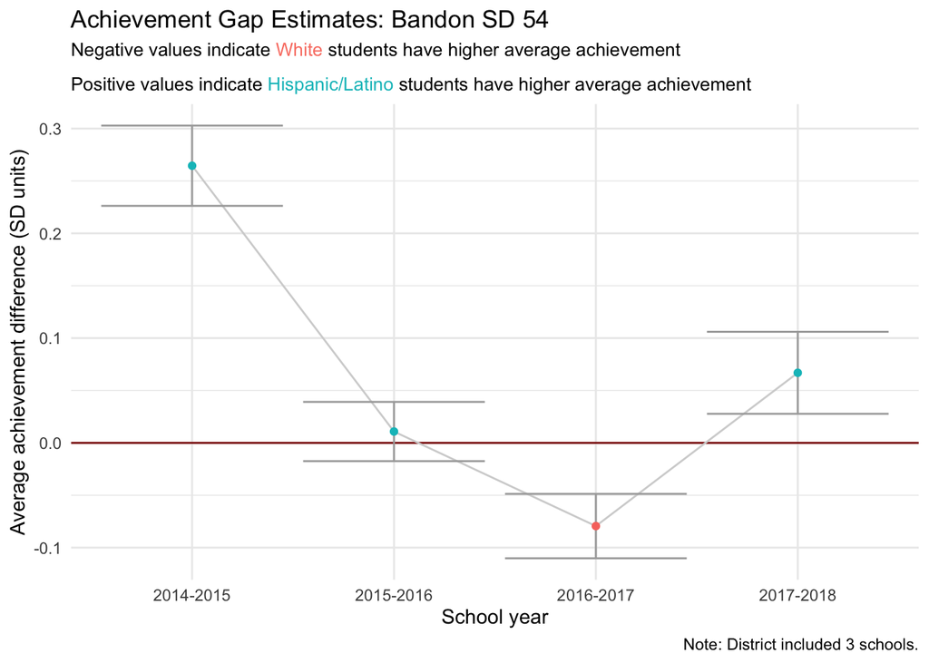

```r
# method 2: nest_by()
ode_plots2 <- analysisprime |>
  ungroup() |>
  nest_by(district) |>
  mutate(
    plot = list(ggplot(data, aes(x=academic_year)) +
                  # asked gemini how to make the next line "how to make
                  # error bars for a geom point based on an error value"
                  theme_minimal() +
                  geom_hline(yintercept = 0, color = "darkred") +
                  geom_line(aes(y=v), color = "lightgrey", group = 1, size = 0.5) +
                  geom_errorbar(aes(ymin = v - v_se, ymax = v + v_se), color="darkgrey") +
                  geom_point(aes(y = v, color = v>0)) +
                  labs(
                    title = paste0("Achievement Gap Estimates: ", district),
                    subtitle = "Negative values indicate <span style='color:salmon;'>White</span> students have higher average achievement\n\nPositive values indicate <span style='color:#00BFC4;'>Hispanic/Latino</span> students have higher average achievement",
                    x = "School year",
                    y = "Average achievement difference (SD units)",
                    caption = paste0(
                      "Note: District included ",
                      data$n_schools[[1]],
                      " schools.")
                  ) +
                  theme(
                    plot.subtitle = element_markdown(size=10),
                    legend.position = "none"
                  )
    )
  )

ode_plots2$plot[[7]]
```

### 4. (10 points)

Save the plots into a “plots” directory. Make sure the file names are meaningful.

```r
ode_plots1 |>
  ungroup() |>
  rowwise() |>
  summarize(
    ggsave(
      here(paste0(
        "plots/v1/",
        str_replace_all(
          tolower(district), " ", "-"
        ),
        "-achievement-gap-v1.png")
      ),
      plot,
      width = 9.5,
      height = 6.5,
      dpi = 500
    )
  )
```

```
`geom_line()`: Each group consists of only one observation.
ℹ Do you need to adjust the group aesthetic?
```

```
# A tibble: 100 × 1
   `ggsave(...)`
   <chr>
 1 /Users/stmii/EDLD 653/midterm/plots/v1/adrian-sd-61-achievement-gap-v1.png
 2 /Users/stmii/EDLD 653/midterm/plots/v1/amity-sd-4j-achievement-gap-v1.png
 3 /Users/stmii/EDLD 653/midterm/plots/v1/ashland-sd-5-achievement-gap-v1.png
 4 /Users/stmii/EDLD 653/midterm/plots/v1/astoria-sd-1-achievement-gap-v1.png
 5 /Users/stmii/EDLD 653/midterm/plots/v1/athena-weston-sd-29rj-achievement-gap…
 6 /Users/stmii/EDLD 653/midterm/plots/v1/baker-sd-5j-achievement-gap-v1.png
 7 /Users/stmii/EDLD 653/midterm/plots/v1/bandon-sd-54-achievement-gap-v1.png
 8 /Users/stmii/EDLD 653/midterm/plots/v1/banks-sd-13-achievement-gap-v1.png
 9 /Users/stmii/EDLD 653/midterm/plots/v1/beaverton-sd-48j-achievement-gap-v1.p…
10 /Users/stmii/EDLD 653/midterm/plots/v1/bend-lapine-administrative-sd-1-achie…
# ℹ 90 more rows
```

```r
ode_plots2 |>
  ungroup() |>
  rowwise() |>
  summarize(
    ggsave(
      here(paste0(
        "plots/v2/",
        str_replace_all(
          tolower(district), " ", "-"
        ),
        "-achievement-gap-v2.png")
      ),
      plot,
      width = 9.5,
      height = 6.5,
      dpi = 500
    )
  )
```

```
`geom_line()`: Each group consists of only one observation.
ℹ Do you need to adjust the group aesthetic?
```

```
# A tibble: 100 × 1
   `ggsave(...)`
   <chr>
 1 /Users/stmii/EDLD 653/midterm/plots/v2/adrian-sd-61-achievement-gap-v2.png
 2 /Users/stmii/EDLD 653/midterm/plots/v2/amity-sd-4j-achievement-gap-v2.png
 3 /Users/stmii/EDLD 653/midterm/plots/v2/ashland-sd-5-achievement-gap-v2.png
 4 /Users/stmii/EDLD 653/midterm/plots/v2/astoria-sd-1-achievement-gap-v2.png
 5 /Users/stmii/EDLD 653/midterm/plots/v2/athena-weston-sd-29rj-achievement-gap…
 6 /Users/stmii/EDLD 653/midterm/plots/v2/baker-sd-5j-achievement-gap-v2.png
 7 /Users/stmii/EDLD 653/midterm/plots/v2/bandon-sd-54-achievement-gap-v2.png
 8 /Users/stmii/EDLD 653/midterm/plots/v2/banks-sd-13-achievement-gap-v2.png
 9 /Users/stmii/EDLD 653/midterm/plots/v2/beaverton-sd-48j-achievement-gap-v2.p…
10 /Users/stmii/EDLD 653/midterm/plots/v2/bend-lapine-administrative-sd-1-achie…
# ℹ 90 more rows
```